# market share 1

Yutaka Kuroki

2018/12/10

```r
library(tidyverse)
library(lubridate)
library(dbplyr)
library(dbplot)
library(RPostgreSQL)

theme_set(theme_bw(base_family = "HiraKakuPro-W3"))
```

```r
conn <- dbConnect(PostgreSQL(),
                  host = scan("connection.txt", what = character())[1],
                  port = scan("connection.txt", what = character())[2],
                  dbname = scan("connection.txt", what = character())[3],
                  user = scan("connection.txt", what = character())[4],
                  password = scan("connection.txt", what = character())[5])

orgn2 <- conn %>%
  tbl(from = dbplyr::in_schema("edit", "tv_orgn_program_2"))
orgn <- conn %>%
  tbl(from = dbplyr::in_schema("processed", "tv_orgn_p_cv"))
program <- conn %>%
  tbl(from = dbplyr::in_schema("processed", "tv_program"))
ban <- conn %>%
  tbl(from = dbplyr::in_schema("processed", "bancluster_mst"))
ban1 <- conn %>%
  tbl(from = dbplyr::in_schema("sub_mst", "ban_code1_mst"))
ban2 <- conn %>%
  tbl(from = dbplyr::in_schema("sub_mst", "ban_code2_mst"))
prof_data <- conn %>%
  tbl(from = dbplyr::in_schema("processed", "profiledata"))
prof_mst <- conn %>%
  tbl(from = dbplyr::in_schema("processed", "profilemaster"))
prof <- prof_data %>%
  left_join(prof_mst, by = c("qu_genre_code", "question_code", "answer_code"))
sta <- conn %>%
  tbl(from = dbplyr::in_schema("processed", "sta_mst"))

## CM
jiten <- conn %>%
  tbl(from = dbplyr::in_schema("processed", "jiten_data"))
brand <- conn %>%
  tbl(from = dbplyr::in_schema("processed", "m_cm_tv_brand"))
adv <- conn %>%
  tbl(from = dbplyr::in_schema("processed", "m_cm_tv_advertiser"))

# watch_rate <- read_csv("data/processed/watch_rate.csv")

res <- read_rds("data/results_nmf.rds")
res2 <- read_rds("data/results_nmf2.rds")
res <- c(res, res2)
```

# 1 introduction

視聴者という有限な資源を複数のエージェント（キー局）が取り合っている，という視点からデータを眺めてみる．  
例えばドラマというものを例にあげると，

1. 俳優や原作についているコア視聴者
2. ドラマというエンターテイメントが好きな視聴者
3. 暇なのでとりあえずドラマを見ている視聴者

が考えられる．1や2の視聴者は，「ドラマがつまらなかったら切る」 or 「話題になったら見始める」といった行動をとると考えられる

# 2

```r
watch_time_sta <- orgn %>%
  filter(data_agg_type == 1) %>%
  mutate(watch_time = br_end_datetime - br_start_datetime)%>%
  group_by(station_code) %>%
  summarise(watch_time = sum(watch_time, na.rm=TRUE)) %>%
  collect() %>%
  mutate(watch_time = as.integer(str_sub(watch_time, 1, -7)))
```

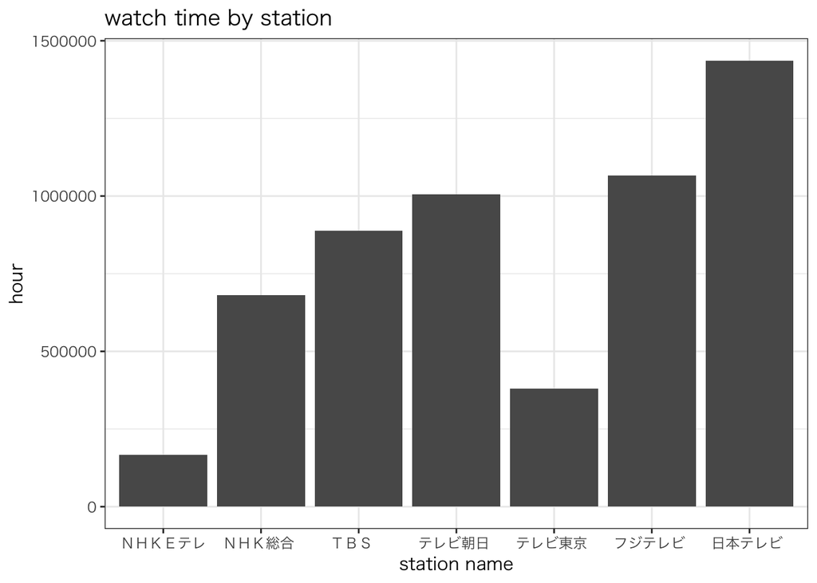

```r
watch_time_sta %>%
  left_join(collect(sta), by = "station_code") %>%
  ggplot(aes(station_jp, watch_time))+
  geom_bar(stat = "identity")+
  labs(y = "hour", x = "station name",
       title = "watch time by station")
```

```r
program_time_sta <- program %>%
  group_by(station_code) %>%
  summarise(program_time = sum(program_time, na.rm = TRUE)) %>%
  collect()
```

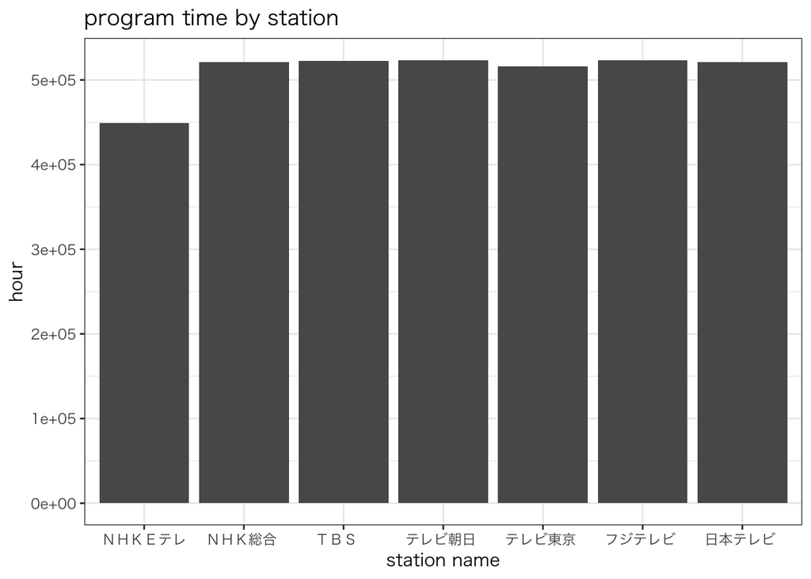

```r
program_time_sta %>%
  left_join(collect(sta), by = "station_code") %>%
  ggplot(aes(station_jp, program_time))+
  geom_bar(stat = "identity")+
  labs(y = "hour", x = "station name",
       title = "program time by station")
```

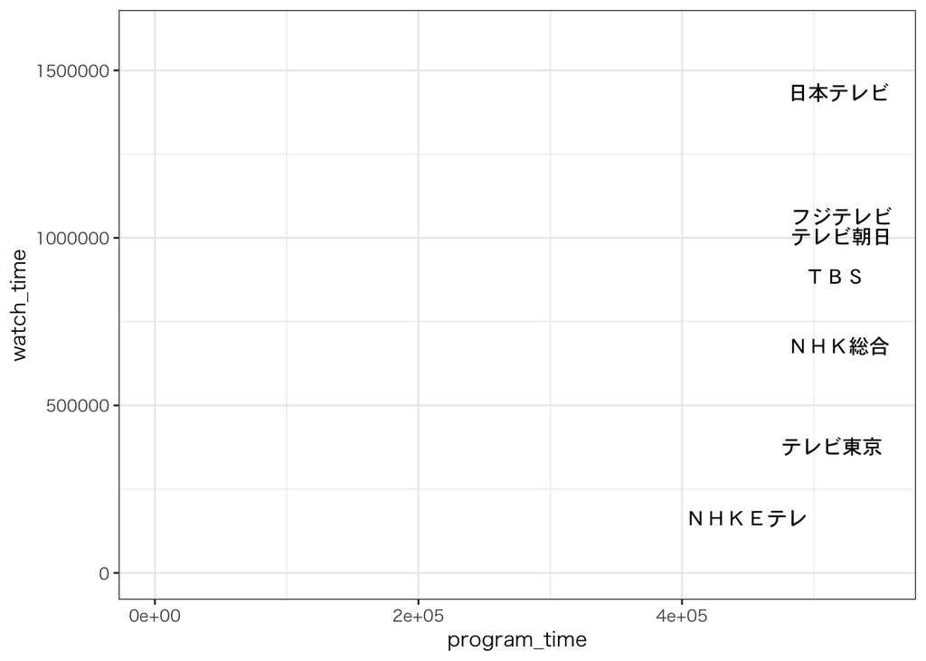

```r
program_time_sta %>%
  left_join(watch_time_sta, by = "station_code") %>%
  left_join(collect(sta), by = "station_code") %>%
  ggplot(aes(program_time, watch_time))+
  geom_text(aes(label = station_jp), family = "Osaka")+
  scale_x_continuous(limits = c(0,550000))+
  scale_y_continuous(limits = c(0,1600000))
```

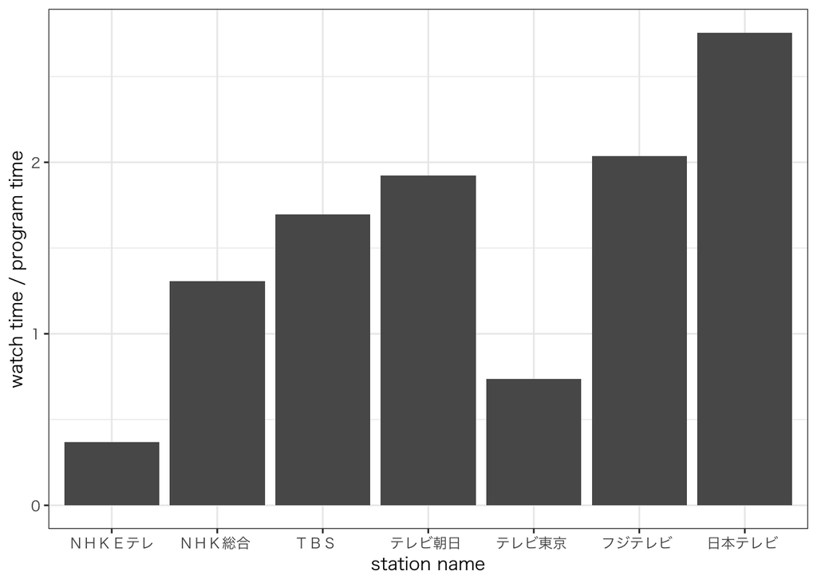

```r
program_time_sta %>%
  left_join(watch_time_sta, by = "station_code") %>%
  left_join(collect(sta), by = "station_code") %>%
  mutate(watch_time_program_time = watch_time / program_time) %>%
  ggplot(aes(station_jp, watch_time_program_time))+
  geom_bar(stat = "identity")+
  labs(x = "station name", y = "watch time / program time")
```

# 3 全体のシェア

データ期間全体を通してテレビ視聴時間の増減はなさそう  
というかデータ期間が1年しかないので年周期なのかテレビ視聴時間の増減なのかわからない

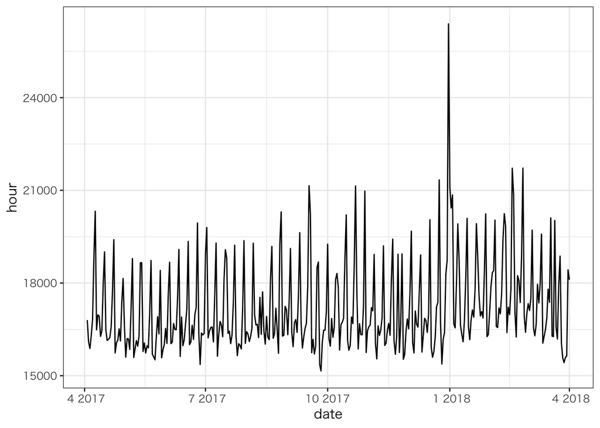

```r
watch_time_daily <- orgn %>%
  mutate(watch_time = br_end_datetime - br_start_datetime) %>%
  group_by(br_date)%>%
  summarise(watch_time = sum(watch_time, na.rm=TRUE)) %>%
  collect()

watch_time_daily %>%
  mutate(watch_time = as.integer(str_sub(watch_time, 1, -7))) %>%
  ggplot(aes(br_date, watch_time))+
  geom_line()+
  labs(x = "date", y = "hour")
```

## 3.1 チャンネルごと

- 紅白ヤベーって感じ．
- 日テレのスパイクはなんだ？年末年始と9月頭？
- TBSが1週間内の変動が大きい．どこかに強い番組を固めてる曜日がある？

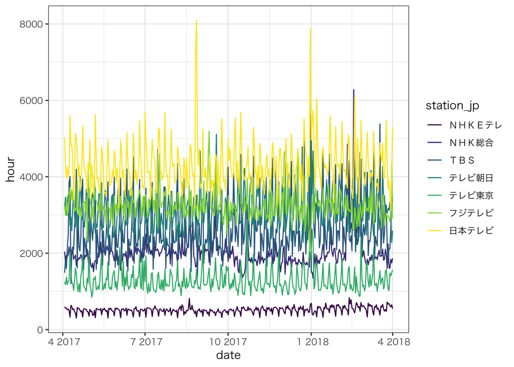

```r
watch_time_daily_sta <- orgn %>%
  mutate(watch_time = br_end_datetime - br_start_datetime) %>%
  group_by(br_date, station_code)%>%
  summarise(watch_time = sum(watch_time, na.rm=TRUE)) %>%
  collect() %>%
  ungroup()

watch_time_daily_sta %>%
  mutate(watch_time = as.integer(str_sub(watch_time, 1, -7))) %>%
  left_join(collect(sta), by = "station_code") %>%
  ggplot(aes(br_date, watch_time, group = station_jp, colour = station_jp))+
  geom_line()+
  labs(x = "date", y = "hour")+
  scale_colour_viridis_d()
```

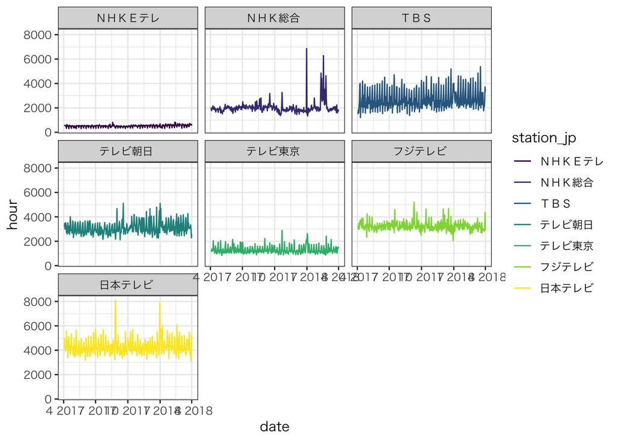

```r
watch_time_daily_sta %>%
  mutate(watch_time = as.integer(str_sub(watch_time, 1, -7))) %>%
  left_join(collect(sta), by = "station_code") %>%
  ggplot(aes(br_date, watch_time, group = station_jp, colour = station_jp))+
  geom_line()+
  labs(x = "date", y = "hour")+
  facet_wrap(~station_jp)+
  scale_colour_viridis_d()
```

時系列プロットを見てもよく分からないので積み上げ折れ線グラフを書いてみる

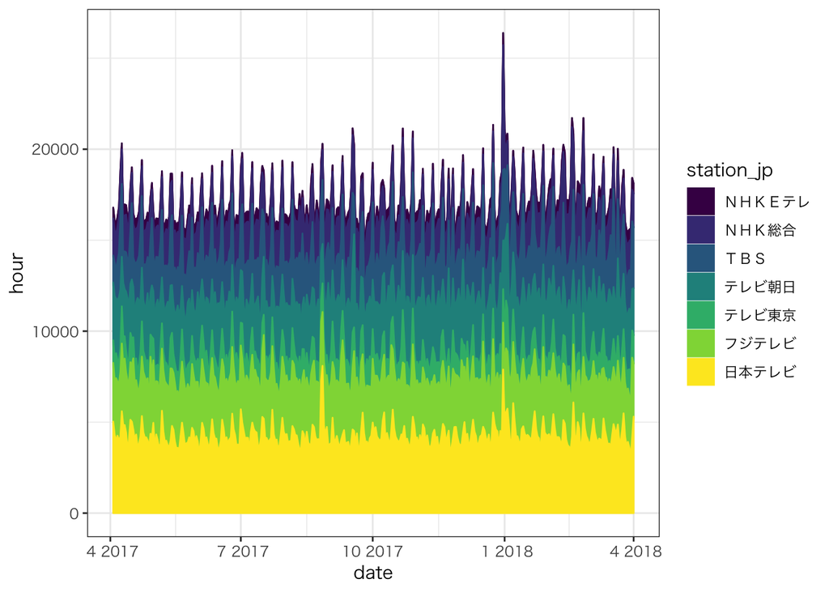

```r
watch_time_daily_sta %>%
  mutate(watch_time = as.integer(str_sub(watch_time, 1, -7))) %>%
  left_join(collect(sta), by = "station_code") %>%
  ggplot(aes(br_date, watch_time, group = station_jp, colour = station_jp, fill=station_jp))+
  geom_line(position="stack")+
  geom_ribbon(aes(ymin = 0, ymax = watch_time), position = "stack")+
  labs(x = "date", y = "hour")+
  scale_colour_viridis_d()+
  scale_fill_viridis_d()
```

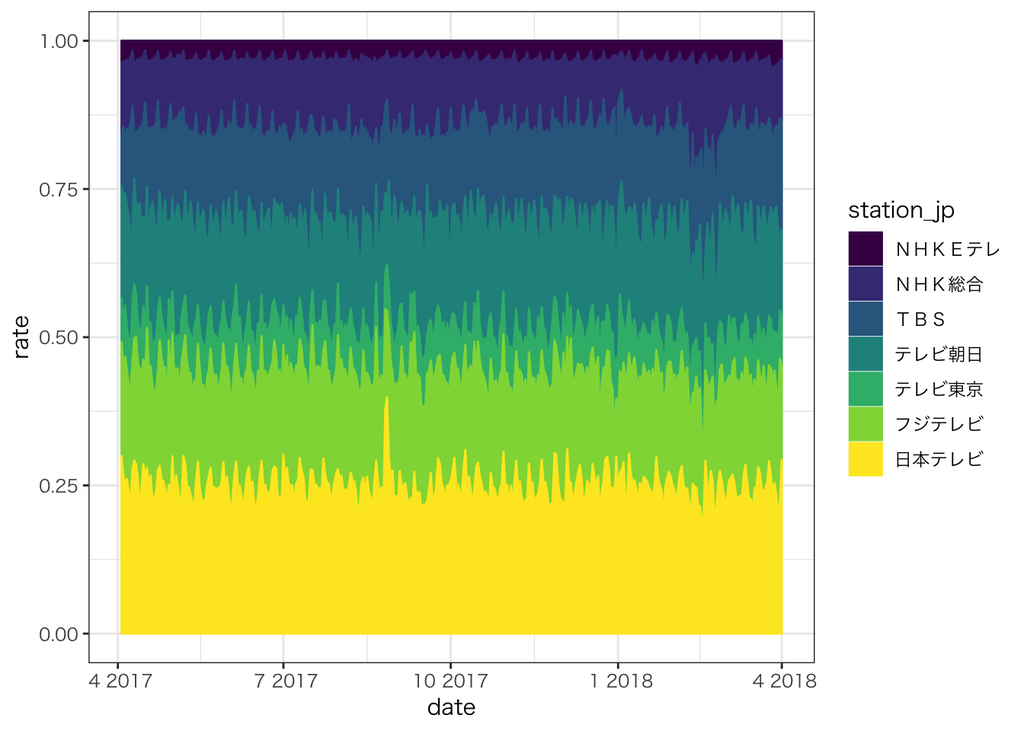

```r
watch_time_daily_sta %>%
  mutate(watch_time = as.integer(str_sub(watch_time, 1, -7))) %>%
  group_by(br_date) %>%
  mutate(rate = watch_time / sum(watch_time))%>%
  left_join(collect(sta), by = "station_code") %>%
  ggplot(aes(br_date, rate, group = station_jp, colour = station_jp, fill=station_jp))+
  geom_line(position="stack")+
  geom_ribbon(aes(ymin = 0, ymax = rate), position = "stack")+
  labs(x = "date", y = "rate")+
  scale_colour_viridis_d()+
  scale_fill_viridis_d()
```

dailyで見てもよくわからないのでweeklyでみる

- ほぼ横ばい
- ハンドリングが面倒臭くて2017年と2018年の切れ目がうまくいってないので折れ線の方では大変一瞬0に近づいている
- NHKの2月中旬がやたらシェア大きい（大晦日並）なのは何かがあるんでしょうか

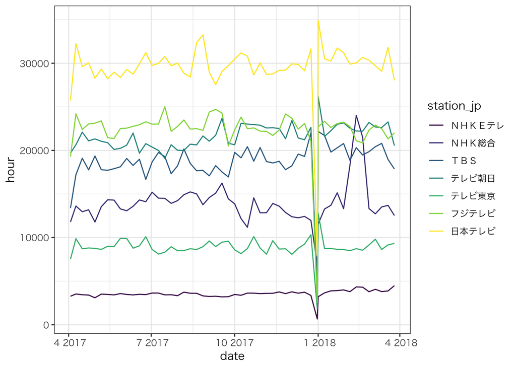

```r
watch_time_daily_sta %>%
  mutate(watch_time = as.integer(str_sub(watch_time, 1, -7))) %>%
  group_by(week = week(br_date)) %>%
  mutate(br_date = min(br_date)) %>%
  group_by(br_date, station_code) %>%
  summarise(watch_time = sum(watch_time)) %>%
  left_join(collect(sta), by = "station_code") %>%
  ggplot(aes(br_date, watch_time, group = station_jp, colour = station_jp))+
  geom_line()+
  labs(x = "date", y = "hour")+
  scale_colour_viridis_d()
```

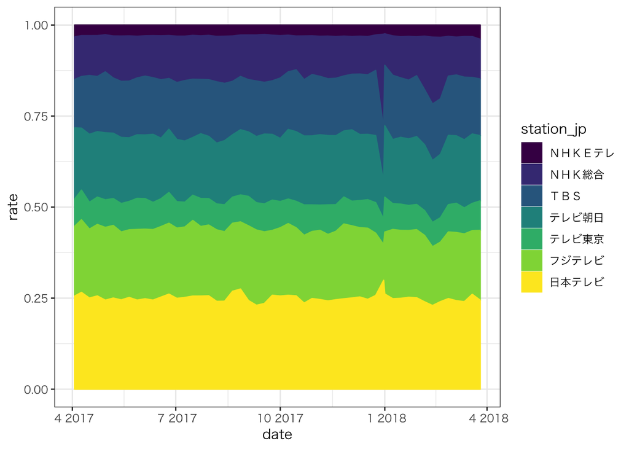

```r
watch_time_daily_sta %>%
  mutate(watch_time = as.integer(str_sub(watch_time, 1, -7))) %>%
  group_by(week = week(br_date)) %>%
  mutate(br_date = min(br_date)) %>%
  group_by(br_date, station_code) %>%
  summarise(watch_time = sum(watch_time)) %>%
  mutate(rate = watch_time / sum(watch_time))%>%
  left_join(collect(sta), by = "station_code") %>%
  ggplot(aes(br_date, rate, group = station_jp, colour = station_jp, fill=station_jp))+
  geom_line(position="stack")+
  geom_ribbon(aes(ymin = 0, ymax = rate), position = "stack")+
  labs(x = "date", y = "rate")+
  scale_colour_viridis_d()+
  scale_fill_viridis_d()
```

# 4 ドラマに絞っていく

br_start_datetime br_end_datetime br_day_week house_num station_code tv_num data_agg_type data_seq br_date program_code program_date program_start_time program_time program_end_time ban_code1 ban_code2

```r
orgn %>%
  select(br_start_datetime, br_end_datetime, house_num, station_code, data_agg_type, br_date) %>%
  left_join(select(program,
                   station_code, program_code, program_date, program_start_time, program_end_time),
            by = c("br_date" = "program_date", "station_code")) %>%
  filter(program_start_time < br_end_datetime,
         program_end_time > br_start_datetime) %>%
  mutate(flag1 = br_start_datetime < program_start_time,
         flag2 = br_end_datetime < program_end_time) %>%
  mutate(br_start_datetime = if_else(flag1==TRUE, program_start_time, br_start_datetime),
         br_end_datetime = if_else(flag2 == TRUE, br_end_datetime, program_end_time)) %>%
  select(-flag1, -flag2)
```

```
## # Source:   lazy query [?? x 9]
## # Database: postgres 8.3.23 [m1@133.31.57.120:5222/video]
##    br_start_datetime   br_end_datetime     house_num station_code
##    <dttm>              <dttm>                  <int>        <int>
##  1 2017-06-06 00:01:00 2017-06-06 00:02:00        47            1
##  2 2017-06-06 00:25:00 2017-06-06 00:29:00        67            4
##  3 2017-06-05 06:56:00 2017-06-05 07:00:00       145            4
##  4 2017-06-05 07:00:00 2017-06-05 07:58:00       145            4
##  5 2017-06-05 20:06:00 2017-06-05 20:12:00       156            1
##  6 2017-06-05 21:22:00 2017-06-05 21:51:00       171            4
##  7 2017-06-05 08:14:00 2017-06-05 08:14:00       208            6
##  8 2017-06-05 07:13:00 2017-06-05 07:18:00       372            4
##  9 2017-06-05 19:00:00 2017-06-05 19:29:00       418            6
## 10 2017-06-05 18:30:00 2017-06-05 19:00:00       418            6
## # ... with more rows, and 5 more variables: data_agg_type <int>,
## #   br_date <date>, program_code <chr>, program_start_time <dttm>,
## #   program_end_time <dttm>
```

ドラマがかなり面白そうでは？？

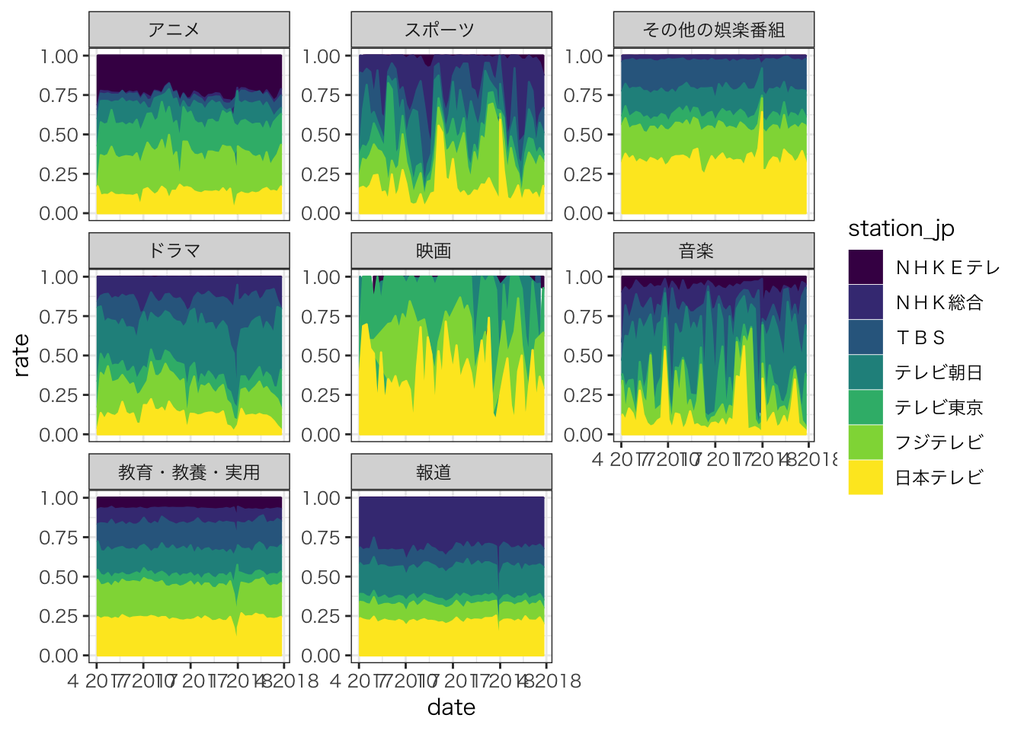

```r
true_watch <- orgn %>%
  left_join(select(program,
                   station_code, program_code, program_date, program_start_time, program_end_time),
            by = c("br_date" = "program_date", "station_code")) %>%
  filter(program_start_time < br_end_datetime,
         program_end_time > br_start_datetime) %>%
  mutate(flag1 = br_start_datetime < program_start_time,
         flag2 = br_end_datetime < program_end_time) %>%
  mutate(br_start_datetime = if_else(flag1==TRUE, program_start_time, br_start_datetime),
         br_end_datetime = if_else(flag2 == TRUE, br_end_datetime, program_end_time)) %>%
  select(-flag1, -flag2)

daily_watch <- true_watch %>%
  left_join(program, by = c("station_code", "program_code", "program_start_time", "program_end_time")) %>%
  group_by(station_code, br_date, ban_code1) %>%
  summarise(watch_time = sum(br_end_datetime - br_start_datetime, na.rm=TRUE)) %>%
  ungroup() %>%
  collect()


daily_watch %>%
  left_join(collect(ban1), by = "ban_code1") %>%
  mutate(watch_time = as.integer(str_sub(watch_time, 1, -7)),
         week = week(br_date),
         year = year(br_date)) %>%
  group_by(year, week) %>%
  mutate(br_date = min(br_date)) %>%
  group_by(br_date, station_code, ban_code1_naiyou) %>%
  summarise(watch_time = sum(watch_time)) %>%
  group_by(br_date, ban_code1_naiyou) %>%
  mutate(rate = watch_time / sum(watch_time)) %>%
  left_join(collect(sta), by = "station_code") %>%
  ggplot(aes(br_date, rate, group = station_jp, colour = station_jp, fill=station_jp))+
  geom_line(position="stack")+
  geom_ribbon(aes(ymin = 0, ymax = rate), position = "stack")+
  labs(x = "date", y = "rate")+
  scale_colour_viridis_d()+
  scale_fill_viridis_d()+
  facet_wrap(~ban_code1_naiyou, scale = "free_y")
```